# Packet 7 - Comparing Two Proportions

Todd CadwalladerOlsker

*Last updated:* 2022-04-14

## Two-proportion hypothesis tests

A recent study investigated whether or not ivermectin (an anti-parasitic used in animal care) could be used to treat Covid-19. In order to investigate this, researchers randomly assigned patients who had recently contracted Covid-19 to either a treatment group or a placebo group. Then, researchers recorded the number of patients in each group that had a “hospitalization event”, meaning the patient either was hospitalized or spent an extended amount of time in an emergency department.

Read more about the study here: https://www.cidrap.umn.edu/news-perspective/2022/03/ivermectin-doesnt-prevent-covid-hospital-cases-large-study-finds

The main result is the following:

```r
num_iver <- 679
event_iver <- 100
num_iplacebo <- 679
event_iplacebo <- 111

iver_study <- matrix(c(event_iver, num_iver - event_iver,
                       event_iplacebo, num_iplacebo - event_iplacebo),
                     ncol=2, byrow=TRUE)
colnames(iver_study) <- c("event", "no event")
rownames(iver_study) <- c("ivermectin", "placebo")
iver_study <- as.table(iver_study)

iver_study_margins <- iver_study %>% addmargins(2)
iver_study_margins
```

```
##            event no event Sum
## ivermectin   100      579 679
## placebo      111      568 679
```

```r
iver_props <- iver_study %>% prop.table(1) %>% addmargins(2)
iver_props
```

```
##                event  no event       Sum
## ivermectin 0.1472754 0.8527246 1.0000000
## placebo    0.1634757 0.8365243 1.0000000
```

In the study, the proportion of events in the ivermectin group was slightly lower (14.7%) than that of the placebo group (16.3). However, does that allow us to infer that the proportion of events would be lower in the *population* of Covid-19 patients? Or is this likely due to chance, when the patients were randomly assigned to groups?

## Using a theoretical distribution

First, we need a statistic to summarize the information we have in a single value. The most natural is the *difference in the proportions*, $\hat{p_1} - \hat{p_2}$.

The standard error for this statistic is given by
$$\sqrt{\frac{\hat{p_1}(1-\hat{p_1})}{n_1}+\frac{\hat{p_2}(1-\hat{p_2})}{n_2}}$$

We can conduct a hypothesis test, with the null hypothesis that $p_1 - p_2 = 0$ – that is, there is no difference between the two populations. Our alternative hypothesis is one of:
$$\begin{align}
p_1 - p_2 &\ne 0 \\
p_1 - p_2 &> 0 \\
p_1 - p_2 &< 0 \\
\end{align}$$

For the ivermectin data we have, either the first or third option would make sense, since in the samples we have, the proportion of events is slightly lower in the first (ivermectin) group than in the second (placebo) group. Let’s run a two-tailed test, using the standard error formula to compute a z-score:

```r
iver_props <- iver_study %>% prop.table(1) %>% addmargins(2)
p_hat_1 <- iver_props["ivermectin","event"]
p_hat_2 <- iver_props["placebo","event"]
n_1 <- iver_study_margins["ivermectin","Sum"]
n_2 <- iver_study_margins["placebo","Sum"]
null_prop <- 0

diff_props <- p_hat_1 - p_hat_2
se <- sqrt((p_hat_1 * (1 - p_hat_1)/n_1) + (p_hat_2 * (1 - p_hat_2)/n_2))
z <- (diff_props - null_prop)/se

pnorm(-abs(z),0,1)+(1-pnorm(abs(z),0,1))
```

```
## [1] 0.4098307
```

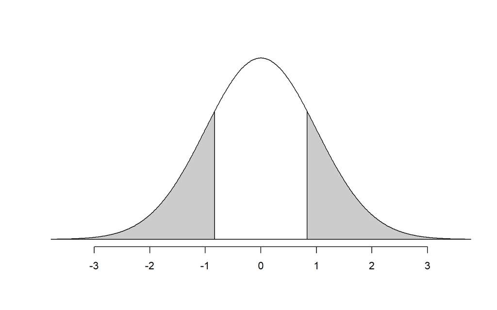

```r
normTail(L = -abs(z), U = abs(z))
```

We can use the same built-in R function, `prop.test`, to compare the proportions of two groups.

```r
iver_study
```

```
##            event no event
## ivermectin   100      579
## placebo      111      568
```

```r
prop.test(iver_study, correct = F)
```

```
##
##  2-sample test for equality of proportions without continuity
##  correction
##
## data:  iver_study
## X-squared = 0.67895, df = 1, p-value = 0.4099
## alternative hypothesis: two.sided
## 95 percent confidence interval:
##  -0.05472531  0.02232472
## sample estimates:
##    prop 1    prop 2
## 0.1472754 0.1634757
```

The `prop.test` function also gives us a confidence interval, which we can calculate by hand:

```r
lower_bound <- diff_props - 1.96 * se
upper_bound <- diff_props + 1.96 * se
c(lower_bound, upper_bound)
```

```
## [1] -0.05472601  0.02232542
```

## Randomization-based hypothesis test and bootstrap confidence interval

To test against the null hypothesis of $p_1 - p_2 = 0$, we want to create a null distribution under the assumption that there really is no difference between the groups. In our ivermectin study, the null hypothesis is that each person with an “event” should be equally likely to be in the placebo group as they are in the treatment group (weighted by the size of each group, but in our example, the groups are the same size).

Let’s use our table to create a data set:

```r
iver_groups <- c(rep("ivermectin", num_iver),
                      rep("placebo", num_iplacebo))
iver_results <- c(rep("event", event_iver),
                  rep("no event", num_iver - event_iver),
                  rep("event", event_iplacebo),
                  rep("no event", num_iplacebo - event_iplacebo))
iver_data <- data.frame("groups" = iver_groups,
                        "results" = iver_results)
```

Inspect the `iver_data` object before continuing. Also try running `iver_data %>% table() %>% addmargins()`.

Now, if each person is equally likely to be in the placebo group as in the treatment group (as in the null hypothesis), we can simulate a new sample by *shuffling* one of the two columns of `iver_data`.

```r
iver_data_shuffled <- iver_data %>%
  mutate(results = sample(results))

iver_data_shuffled %>% table() %>% addmargins()
```

```
##             results
## groups       event no event  Sum
##   ivermectin   109      570  679
##   placebo      102      577  679
##   Sum          211     1147 1358
```

```r
iver_data_shuffled %>% table() %>% prop.table(1) %>% addmargins(2)
```

```
##             results
## groups           event  no event       Sum
##   ivermectin 0.1605302 0.8394698 1.0000000
##   placebo    0.1502209 0.8497791 1.0000000
```

If we do this 10000 times, we will get a good idea of how likely it is that we get a result at least as extreme as our observed $\hat{p_1}-\hat{p_2}$ under the assumption of the null hypothesis:

```r
iver_diff_prop <-
  iver_props["ivermectin","event"] - iver_props["placebo","event"]

simulations <- 10000

sim_diff_prop <- numeric(simulations)

for(i in 1:simulations){
  sim_data_shuffle <- iver_data %>%
    mutate(results = sample(results))
  sim_props <- sim_data_shuffle %>% table() %>% prop.table(1)
  sim_diff_prop[i] <-
    sim_props["ivermectin","event"] - sim_props["placebo","event"]
}

sim_dist <- data.frame(sim_diff_prop)

# Find the number of simulations at least as extreme
# as the test statistic, and calculate p-value.

sims_as_extreme <- sim_dist %>%
  filter(sim_diff_prop <= -abs(iver_diff_prop) |
           sim_diff_prop >= abs(iver_diff_prop)) %>%
  nrow()
sims_as_extreme
```

```
## [1] 4512
```

```r
p_val <- sims_as_extreme/simulations
p_val
```

```
## [1] 0.4512
```

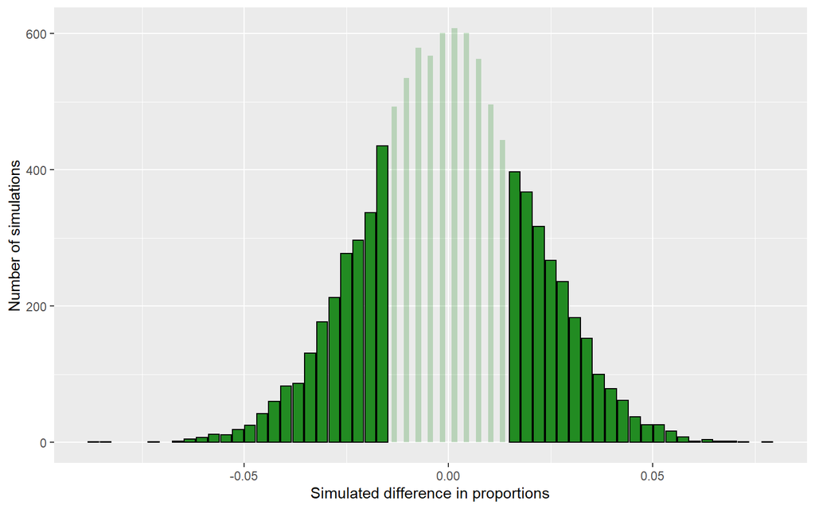

```r
# Visualize the null distribution with our test statistic

sim_dist %>% ggplot(aes(x = sim_diff_prop)) +
  geom_bar(color = "black", fill = "forestgreen") +
  scale_x_continuous() +
  gghighlight(sim_diff_prop <= -abs(iver_diff_prop) |
                sim_diff_prop >= abs(iver_diff_prop)
              ,
              unhighlighted_params = list(
                fill = "forestgreen",
                alpha = 0.25)) +
  labs(
    x = "Simulated difference in proportions",
    y = "Number of simulations"
  )
```

Alternatively, we can use the `infer` package:

```r
# Calculate the test statistic

infer_diff_prop <- iver_data %>%
  specify(results ~ groups, success = "event") %>%
  calculate(stat = "diff in props")
infer_diff_prop
```

```
## Response: results (factor)
## Explanatory: groups (factor)
## # A tibble: 1 x 1
##      stat
##     <dbl>
## 1 -0.0162
```

```r
# create a null distribution

null_dist <- iver_data %>%
  specify(results ~ groups, success = "event") %>%
  hypothesize(null = "independence") %>%
  generate(reps = 10000, type = "permute") %>%
  calculate(stat = "diff in props")

# Identify the number of values at least as extreme in the null dist
# as our test statistic, and calculate a p-value

null_dist %>%
  get_p_value(obs_stat = infer_diff_prop, direction = "two-sided")
```

```
## # A tibble: 1 x 1
##   p_value
##     <dbl>
## 1   0.446
```

We can get a confidence interval by using the bootstrap:

```r
simulations <- 10000
slice_diff_prop <- numeric(simulations)

for(i in 1:simulations){
  sim_data_slice <- iver_data %>%
    slice_sample(n = nrow(.), replace = T)
  slice_props <- sim_data_slice %>% table() %>% prop.table(1)
  slice_diff_prop[i] <-
    slice_props["ivermectin","event"] - slice_props["placebo","event"]
}

boot_dist <- data.frame("diff_prop" = slice_diff_prop)

quantile(boot_dist$diff_prop, probs = c(0.025, 0.975))
```

```
##        2.5%       97.5%
## -0.05472591  0.02219816
```

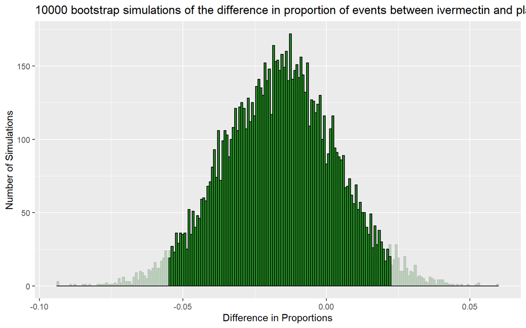

```r
lower_bound <- quantile(boot_dist$diff_prop, probs = c(0.025, 0.975))["2.5%"]
upper_bound <- quantile(boot_dist$diff_prop, probs = c(0.025, 0.975))["97.5%"]

boot_dist %>% ggplot(aes(x = diff_prop)) +
  geom_histogram(binwidth = 1/nrow(iver_data),
           color = "black",
           fill = "forestgreen") +
  gghighlight(upper_bound >= diff_prop &
              lower_bound <= diff_prop,
              unhighlighted_params = list(
                color = "grey",
                fill = "forestgreen",
                alpha = 0.25)) +
  labs(
    title = paste(simulations, "bootstrap simulations of the difference in proportion of events between ivermectin and placebo"),
    x = "Difference in Proportions",
    y = "Number of Simulations"
  )
```

Using `infer`:

```r
infer_diff_prop <- iver_data %>%
  specify(results ~ groups, success = "event") %>%
  calculate(stat = "diff in props")

# create a bootstrap distribution

boot_dist <- iver_data %>%
  specify(results ~ groups, success = "event") %>%
  generate(reps = 10000, type = "bootstrap") %>%
  calculate(stat = "diff in props")

# Calculate the upper and lower bounds of the confidence interval

percentile_ci <- get_ci(boot_dist)
percentile_ci
```

```
## # A tibble: 1 x 2
##   lower_ci upper_ci
##      <dbl>    <dbl>
## 1  -0.0559   0.0217
```

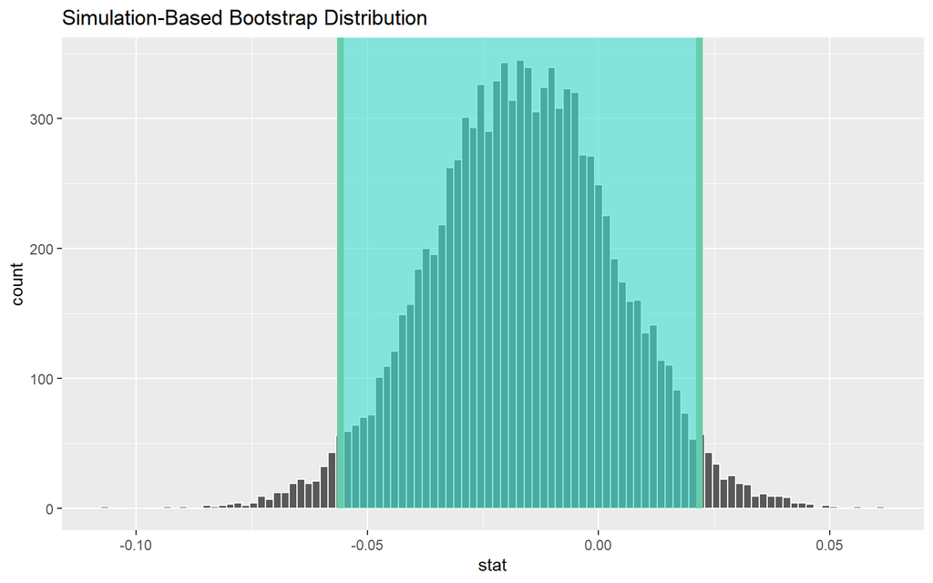

```r
# A vizualization:

boot_dist %>%
  visualize(bins = 100) +
  shade_confidence_interval(endpoints = percentile_ci)
```

## In class activity: Fluvoxamine Study

Another study found that fluvoxamine, an anti-depressant medication, may have some effect in treating Covid-19:

https://www.wired.com/story/better-data-on-ivermectin-is-finally-on-its-way/

In this study, 77 of 739 patients taking fluvoxamine had a hospitalization event, while 109 of 733 patients in the placebo group had an event.

```r
num_fluvox <- 739
event_fluvox <- 77
num_fplacebo <- 733
event_fplacebo <- 109
```

Using similar code to the ivermectin study, find:

1. The difference in the proportions of events in the groups
2. The standard error of the difference, as calculated by the formula
3. The p-value of the difference in a hypothesis test with null hypothesis $p_1 - p_2 = 0$, and alternative $p_1 - p_2 < 0$ (a one-sided test, this time.)
4. The 99% confidence interval calculated using the standard error (and the multiple of the SE you found in Packet 6.)
5. Re-do part 3 with a randomization (permutation) test.
6. Re-do part 4 with a bootstrap.

## The hypergeometric exact test

When looking at a single proportion, we could use the *binomial* distribution to find the exact probability of finding a result as extreme (or more extreme) than our test statistic.

With two proportions, we can do something similar with the *hypergeometric* distribution. In the ivermectin example, we take the perspective that we have exactly 211 hospitalization events in the 1358 patients, of which 679 have been assigned to ivermectin and 679 a placebo. If the 211 events are “randomly” distributed, with equal probability, mong the patients, the probability that exactly 100 of them are ivermectin patients and exactly 111 of them are placebo patents is

$$\frac{\binom{679}{100} \cdot \binom{679}{111}}{\binom{1358}{211}}$$

A result “more extreme” than our data would have fewer events in the ivermectin group, and more in the placebo group. Keeping the total number of events constant, the probabilities of all these events sum up to:

$$\frac{\binom{679}{100} \cdot \binom{679}{111}}{\binom{1358}{211}}
+ \frac{\binom{679}{99} \cdot \binom{679}{112}}{\binom{1358}{211}}
+ \cdots +
\frac{\binom{679}{0} \cdot \binom{679}{211}}{\binom{1358}{211}}$$

We can calculate this in R as:

```r
sum(choose(679,111+(0:100))*choose(679,100-(0:100))/choose(1358,211))
```

```
## [1] 0.2269338
```

This is a one-tailed p-value, to get the two tailed p-value, we can simply multiply by 2:

```r
sum(choose(679,111+(0:100))*choose(679,100-(0:100))/choose(1358,211))*2
```

```
## [1] 0.4538676
```

This is implemented in R as `fisher.test()`:

```r
fisher.test(iver_study, alternative = "two.sided")
```

```
##
##  Fisher's Exact Test for Count Data
##
## data:  iver_study
## p-value = 0.4539
## alternative hypothesis: true odds ratio is not equal to 1
## 95 percent confidence interval:
##  0.6511451 1.1986495
## sample estimates:
## odds ratio
##  0.8838666
```

```r
fisher.test(iver_study, alternative = "two.sided")$p
```

```
## [1] 0.4538676
```

## To Turn In

You will turn in the results of the fluvoxamine study above, written as a “report” which presents the results to someone not in this class. I’ve included guidelines for your report below. For this report, you should include the results of a one-tailed hypothesis test based on randomization, and a bootstrapped 99% confidence interval for the difference between the two proportions.

**Important:** For this report, set the following settings in your R Markdown file. The big change is `echo = F`. This will keep your R code from displaying, but the R output will still show up.

```r
knitr::opts_chunk$set(echo = F,
                      cache = T,
                      eval = T,
                      cache.lazy = F,
                      warning = F)
```

### Fluvoxamine Report Guidelines (Based on the “Monkey Report Guidelines” by Dr. Wynne)

This report should have five clearly labeled sections. I don’t care what font or font size you use (just make it consistent) or how long the report is or anything like that. However, you do need to write each section in complete sentences and complete paragraphs. Treating this report like a set of questions on an in-class worksheet will not earn full credit.

Section 1: Introduction (This section covers Step 1: Ask a research question.)

Provide some background context for the investigation. What is the general topic we are investigating, and why is it interesting or important? What is the research question in this investigation?

Section 2: Methods (This section covers Step 2: Design a study and collect data.)

What is an observational unit in this study? What variable are we recording about each observational unit? Is it categorical or quantitative? What is the population we are interested in? What is the parameter we are interested in? Use an appropriate mathematical symbol to represent it. What is your sample?

Section 3: Data Exploration (This section covers Step 3: Explore the data.)

In this section, you will provide summary tables and graphs to organize and visualize the data collected by the researchers.

Section 4: Statistical Inference (This section covers Step 4: Draw inferences beyond the data.)

The textbook highlights two main pillars of statistical inference to focus on this section: the strength of the evidence of an effect (significance) and the size of the effect (estimation).

Tests of Significance: Identify the two competing explanations and identify which is the null vs. alternative hypothesis. Also write them mathematically in terms of the parameter identified in Section 1.

Perform the first S in the 3S strategy: What is the (test) statistic we want to calculate from each observed or simulated sample? What is its value in the observed sample?

Perform the second S in the 3S strategy: Explain how to create a null distribution model for the study assuming the null hypothesis is correct.

Perform the third S step in the 3S strategy: explain how to obtain the p-value for this test, and identify its value as calculated by R.

How strong is your evidence against the null hypothesis and in favor of the alternative hypothesis? Include a graph showing the null distribution of the test statistic, the position of the observed test statistic, and highlighting the portion of the null distribution that is at least as extreme as the observed test statistic. Write 1-2 sentences to interpret the graph.

Confidence Intervals: The confidence interval we constructed estimates the size of the effect.

What is a confidence interval? Explain in your own words how to obtain a confidence interval using the bootstrap. Use R to find the 99% Confidence Interval for the test statistic based on the bootstrap. Include a graph showing the bootstrap distribution of the test statistic, highlighting the portion of the bootstrap that gives the confidence interval.

Section 5: Conclusion and Discussion (This section covers Step 5: Formulate conclusions and Step 6: Look back and ahead.)

Write a conclusion that answers your research question. Justify your conclusion based on the results of your test of significance. What are the plausible values of your parameter? Do you think there could be a “real world important” reduction in the proportion of hospitalization events using fluvoxamine as a COVID treatment?